# Assignment 04

Deepika Nagesh & Marlyn Bruno

2/25/2022

Github Repository

Data Source Urban Institute Education Data

Screenshot of SSH

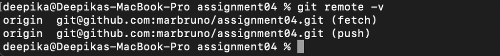

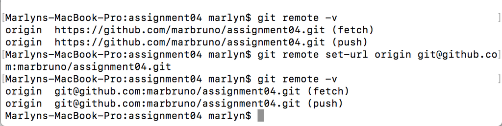

## Student Teacher Ratio by Type of School (Visualization 1)

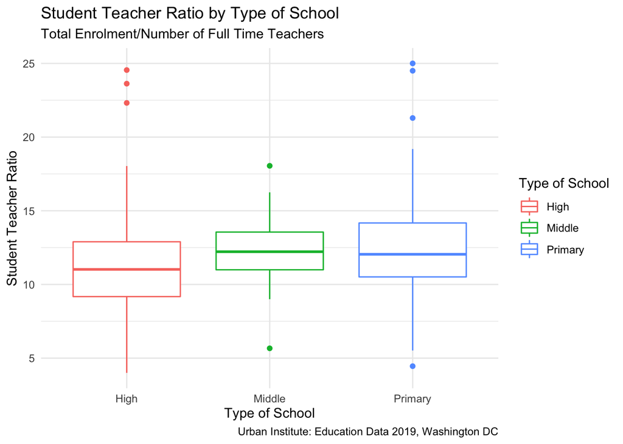

```r
#School to teacher ratio by school level (boxplots)
dcschools %>%
  mutate(ptr = enrollment/teachers_fte) %>%
  filter(school_level == "High"| school_level == "Middle"| school_level =="Primary") %>%
  group_by(school_level) %>%
  filter(ptr < 100) %>%
  ggplot() +
  geom_boxplot(mapping = aes(x = school_level, y = ptr, colour = school_level)) +
  labs (title = "Student Teacher Ratio by Type of School",
  subtitle = "Total Enrolment/Number of Full Time Teachers",
  x = "Type of School",
  y = "Student Teacher Ratio",
  colour = "Type of School",
  caption = "Urban Institute: Education Data 2019, Washington DC") +
  theme(axis.title.x = element_text(size = 13, face = "bold"),
        axis.title.y = element_text(size = 13, face = "bold"),
        axis.text.x= element_text(size = 10, face = "bold"),
        axis.text.y= element_text(size = 10, face = "bold")) +
  theme_minimal()
```

Numerous studies have shown that lower student-to-teacher ratios facilitate a better learning environment for students, especially those in primary school. Our data demonstrates that across high schools, middle schools, and primary schools in DC, most schools (>75%) fall below the national 15.3 average ratio (source: Brookings Institute). Nevertheless, there are numerous outliers in DC high schools and primary schools that could potentially be targeted for class-size reduction policies.

## Student to Teacher Ratio is Not a Good Predictor of Math Proficiency Rates (Vizualization 2)

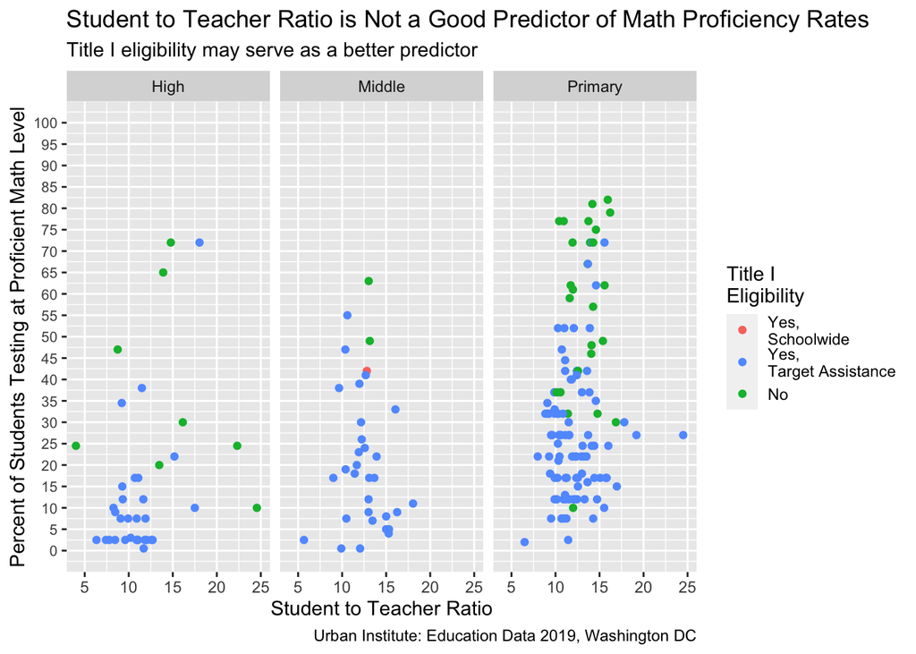

```r
#### Point Chart
dcschools %>%
  filter(school_level == "High"| school_level == "Middle"| school_level =="Primary") %>%
  mutate(student_teacher = enrollment / teachers_fte) %>%
  #mutate (as.numeric(student_teacher)) %>%
  filter(student_teacher < 100) %>%
  ggplot() +
  geom_point(mapping = aes(x = student_teacher, y = as.numeric(as.character(math_test_pct_prof_midpt),alpha = 0.4), color = title_i_schoolwide)) +
  facet_wrap(~ school_level) +
  theme(axis.text.y = element_text(size = 8)) +
  scale_color_discrete(name="Title I\nEligibility",
                        breaks=c("", "Yes", "No"),
                       labels=c("Yes,\nSchoolwide", "Yes,\nTarget Assistance", "No")) +
  labs(
    title = "Student to Teacher Ratio is Not a Good Predictor of Math Proficiency Rates",
    subtitle = "Title I eligibility may serve as a better predictor",
    x = "Student to Teacher Ratio",
    y = "Percent of Students Testing at Proficient Math Level",
    caption = "Urban Institute: Education Data 2019, Washington DC") +
  coord_cartesian() +
  scale_y_continuous(breaks = seq(0, 100, 5),limits=c(0, 100))
```

We mapped out the relationship between the rate of students scoring proficient on a mathematics assessment and the student-to-teacher ratio for each DC school by school level (high school, middle school, or primary school). Most schools have a student-to–teacher ratio concentrated between 10 and 15, but there is no clear indication that lower or higher ratios are correlated with better math assessment proficiency rates. If anything, our graph indicates that a school’s eligibility for Title I funding is a better predictor of proficiency rates. If the District wants to improve math achievement outcomes across all school levels, limiting class room size might not prove an effective policy.

## Title 1 Eligibility by Type of School (Visualization 3)

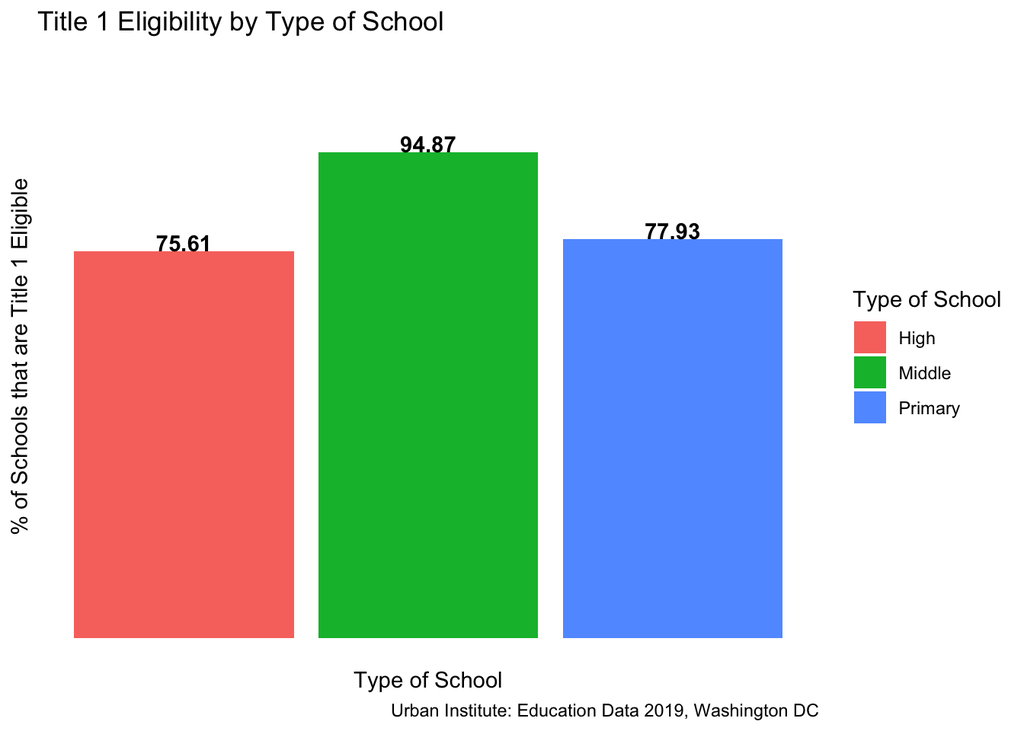

```r
dcschools %>%
  filter (school_level == "High" | school_level == "Middle" |  school_level == "Primary") %>%
  mutate(title1eligible = if_else(title_i_eligible == "Yes", 1, 0)) %>%
  mutate (title1text = if_else(title_i_eligible == "Yes", "Eligible", "Not Eligible")) %>%
  group_by(school_level) %>%
  summarise(title1eligiblemean = mean(title1eligible) * 100) %>%
  ggplot(mapping = aes(x = school_level, y = title1eligiblemean, fill = school_level)) +
  geom_col() +
  labs (title = "Title 1 Eligibility by Type of School",
  x = "Type of School",
  y = "% of Schools that are Title 1 Eligible",
   caption = "Urban Institute: Education Data 2019, Washington DC",
  fill = "Type of School") +
  theme(axis.title.x = element_text(size = 13, face = "bold"),
        axis.title.y = element_text(size = 13, face = "bold"),
        axis.text.x= element_text(size = 10, face = "bold"),
        axis.text.y= element_text(size = 10, face = "bold")) +
  geom_text(aes(label = round(title1eligiblemean, digits = 2),
                y = title1eligiblemean + 0.07,
                fontface = "bold"),
            position = position_dodge(1),
            vjust = 0) +
  theme_minimal() +
  scale_y_continuous(breaks = NULL,limits=c(0, 110)) +
  scale_x_discrete(breaks = NULL)
```

The US Department of Education classifies schools as Title I if students from low-income families make up at least 40 percent of enrollment. Title I funds can be used to target the lowest performing children. Interestingly, ~95% of Middle schools in DC are Title I eligible, yet the majority of Title I-eligible schools have fewer than 50% of the student population testing at a proficient math level (Visualization 2). Similar trends exist for primary schools and high schools: approximately three-fourths of the high schools and primary schools are eligible for Title I funds. The data suggests that DC schools are not receiving adequate funding to note an improvement on students’ math performance despite being eligible under Title I. Further analyses should look at how changes in federal funding over the years has affected math (and reading) proficiency rates.

## Allegations of Harassment Across the District in 2019 (Visualization 4)

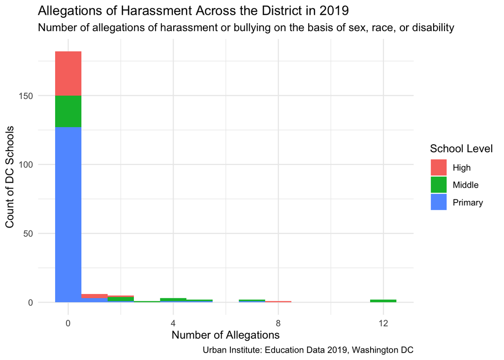

```r
#histogram
dcschools %>%
  filter(school_level == "High"| school_level == "Middle"| school_level =="Primary") %>%
  mutate(harass_sex = as.numeric(allegations_harass_sex)) %>%
  mutate(harass_race = as.numeric(allegations_harass_race)) %>%
  mutate(harass_disability = as.numeric(allegations_harass_disability)) %>%
  mutate(allegations = harass_sex + harass_race + harass_disability) %>%
  ggplot(aes(allegations, fill=school_level)) +
  geom_histogram(binwidth = 1) +
  scale_fill_discrete(name="School Level") +
  labs(
    title = "Allegations of Harassment Across the District in 2019",
    subtitle = "Number of allegations of harassment or bullying on the basis of sex, race, or disability",
    x = "Number of Allegations",
    y = "Count of DC Schools",
     caption = "Urban Institute: Education Data 2019, Washington DC") +
  theme_minimal()
```